# Scaling Relationships for Malaria Metrics

March 15, 2025

Also see [**SimBA**](https://faculty.washington.edu/smitdave/simba/scaling.html)

Load the required packages:

```r
library(ramp.xds)
library(ramp.work)
library(deSolve)
library(viridisLite)
```

Scaling

An important question in malaria is the relationship between various metrics, especially the relationships between mosquito density, the annual entomological inoculation rate (aEIR), the parasite rate (PR), and malaria reproductive numbers. To facilitate analysis of malaria data, we have developed some functions to compute scaling relationships. These are some of the key algorithms we use to generate malaria intelligence assets, and we have two versions:

- `xde_scaling_eir` uses the cohort functions in **`ramp.xds.`** These cohort functions have some advantages in working with exposure in a multiple cohorts as they age, exposed to a common EIR signal.
- `xde_scaling_lambda` uses `xde_solve` in **`ramp.xds.`** These use the trivial **L**-component module to force emergence, and they examine the relationship between mosquito density and all the other metrics.

## xde_scaling_eir

The function `xde_scaling_eir()` defines the relationship between the EIR and the PR. It analyzes stable orbits and outputs the average annual EIR and average annual PR for an even mesh of `log(aEIR)` values running from $10^{-1}$ up to $10^{3}$ The code is in `mob_library/Work`

To illustrate, we pick a function describing a seasonal pattern using `ramp.xds::make_F_sin`

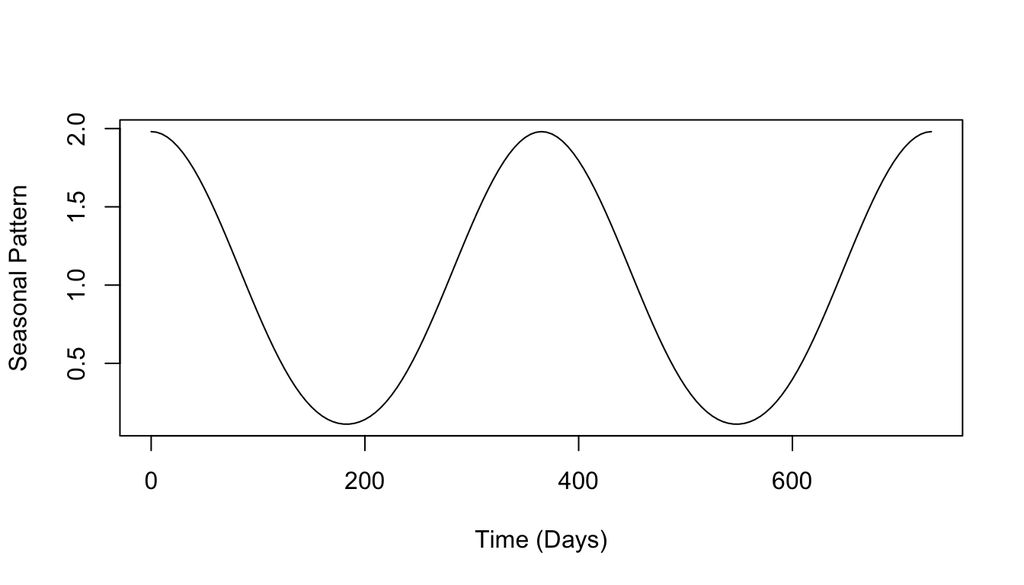

```r
tt <- seq(0, 730, by=5)
p1 <- makepar_F_sin(bottom=0.2, pw=1.2)
Fsin <- make_function(p1)
plot(tt, Fsin(tt), type="l", xlab = "Time (Days)", ylab = "Seasonal Pattern")
```

Next, we set up a cohort model:

```r
xds_setup_cohort(Xname = "SIS", F_season=Fsin) -> sis
```

```r
xds_solve_cohort(sis) -> sis
```

The function `xde_scaling_eir` runs the model over a mesh of `N=25` values:

```r
xde_scaling_eir(sis, 25) -> sis
```

The results are attached as `sis$outputs$eirpr`

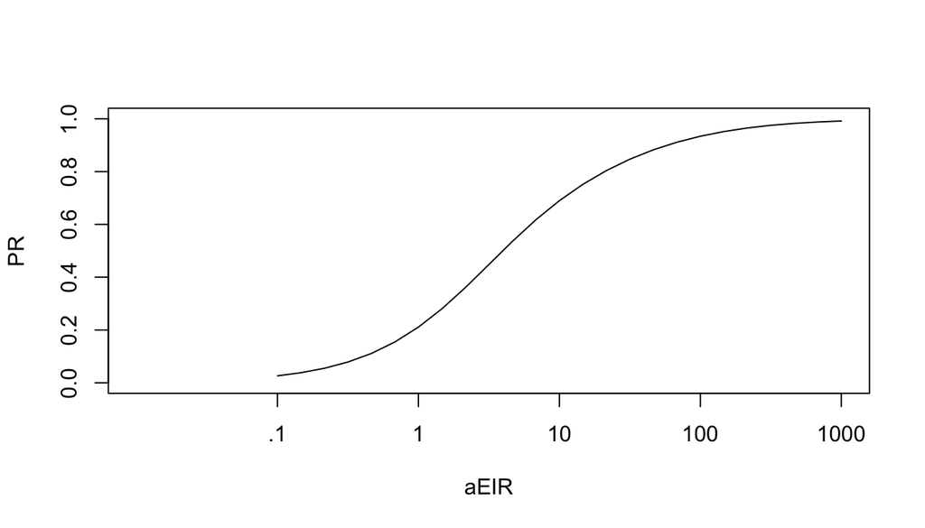

```r
plot_eirpr(sis)
```

```r
eirpr_seasonal_profile(c(5,10,15,20), sis, clrs = turbo(25))
```

[output not shown]

## xde_scaling_lambda

```r
Lo = list(
  F_season = Fsin
)
xds_setup(Xname = "SIS", Lopts=Lo) -> sis_full
```

```r
xds_solve(sis_full) -> sis_full
```

```r
xde_scaling_lambda(sis_full, 1.1, 30) -> sis_full
```

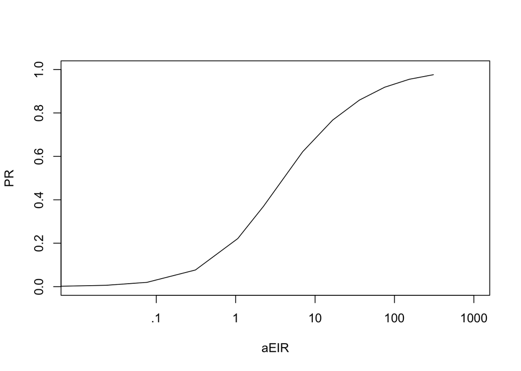

```r
plot_eirpr(sis_full)
```

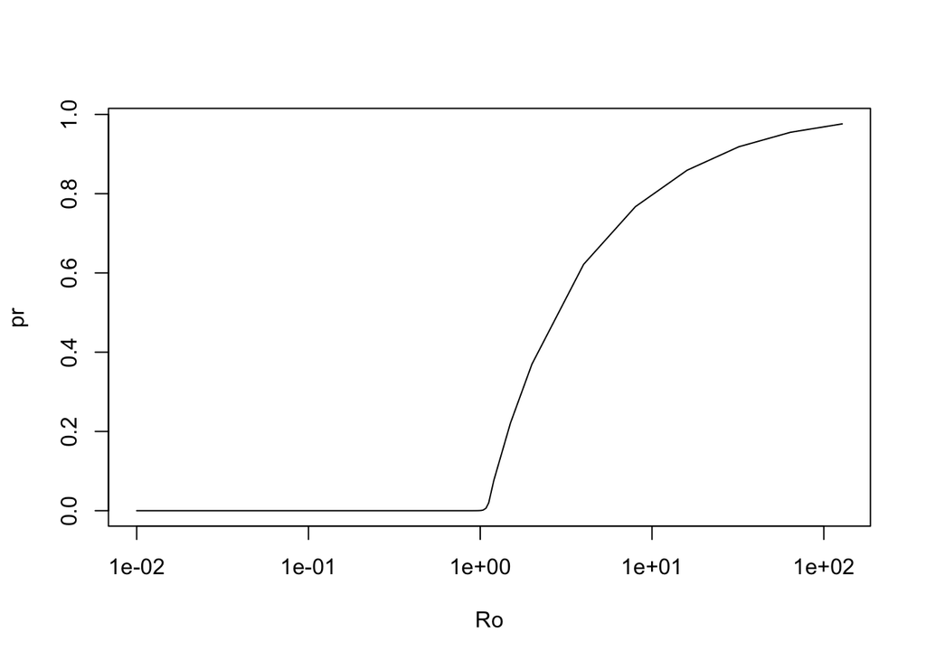

```r
with(sis_full$outputs$eirpr, plot(Ro, pr, type = "l", log="x"))
```

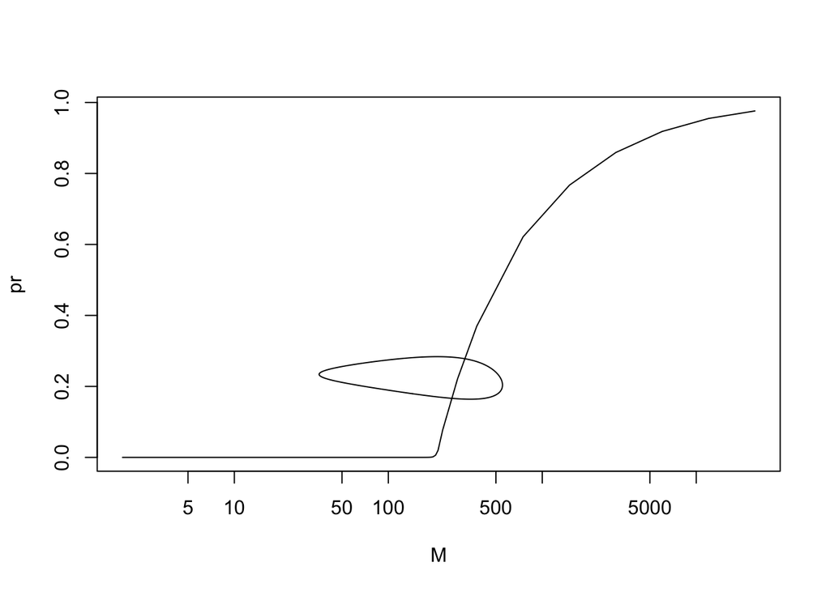

```r
with(sis_full$outputs$eirpr, plot(M, pr, type = "l", log = "x"))
with(sis_full$outputs$eirpr$scaling[[18]], lines(M, pr, type = "l"))
```

## `xde_pr2eir()`

Since `xde_scaling` defines the relationship between the EIR and the PR, we can now run `xde_pr2eir()` to get the predicted value of the eir, for any given value of the pr. The code is in `mob_library/Work`

```r
preir_i = xde_pr2eir(c(0.001, runif(25, 0, 1), 0.999), sis)
```

The function flags any values that are outside of the acceptable range. This may not seem important for the SIS model, but the range of other models can be bounded, so we don’t want to return nonsense values.

```r
preir_i$errors
```

```
##        pr1        pr2        pr3
## 0.00100000 0.02414912 0.99900000
```

We can plot the others:

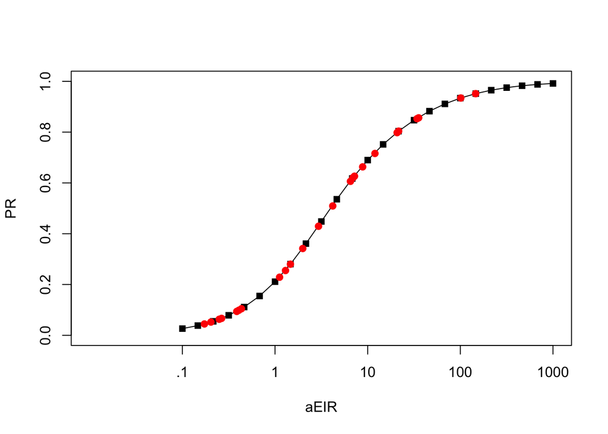

```r
plot_eirpr(sis)
with(sis$outputs$eirpr, points(aeir, pr, pch = 15))
with(preir_i, points(365*eir, pr, pch = 19, col = "red"))
```